# Project: Investigate a Dataset - [No-Show-Appointment Dataset From Kaggle]

- Introduction
- Data Wrangling
- Exploratory Data Analysis
- Conclusions

## Introduction

### Dataset Description

Here is a brief explanation of the columns in the dataset.

- **PatientId** - Identification of a patient
- **AppointmentID** - Identification of each appointment
- **Gender** - Male or Female
- **AppointmentDay** - The day of the actuall appointment, when they have to visit the doctor.
- **ScheduledDay** - The day someone called or registered the appointment, this is before appointment of course.
- **Age**- How old is the patient.
- **Neighbourhood** - Where the appointment takes place.
- **Scholarship** - True of False .Scholarship indicates whether or not the patient is enrolled in Brasilian welfare program [Bolsa Família](https://en.wikipedia.org/wiki/Bolsa_Fam%C3%ADlia).
- **Hipertension** - True=1 or False=0
- **Diabetes** - True=1 or False=0
- **Alcoholism** - True=1 or False=0
- **Handcap** - Level of handicap ranging from 0 - 4
- **SMS_received** - Has 1 or more messages sent to the patient. True=1 or False=0
- **No-show** - Yes or No. If No-show is Yes then it means appointment was missed. If No-show is No then patient made the appointment

### Questions for Analysis

> 1. What proportion of each gender missed their appointments?
> 2. What month, days and periods in the time line have the highest number of No_shows?
> 3. What are the top neighbourhoods with missed appointments?
> 4. What are the proportions of people with health condition that miss their appoinment compared to hose that make their appointment?

```python
# importing all of the packages that you
# plan to use.
import numpy as np
import pandas as pd
import matplotlib.pyplot as plt
import seaborn as sns

#to make visualizations plotted inline with the notebook
%matplotlib inline
```

```python
sns.set() #make all plots use seaborn theme
```

## Data Wrangling

```python
# Firstly, I will load the dataset in this cell
raw = pd.read_csv("noshowappointments-kagglev2-may-2016.csv")
```

Subsequently I will be creating checkpoints. These are just copies of the current state of the dataframe that I would work with instead of a the previous *original copy*. What this helps me do is to easily track back to a *saved point* in case I make a mistake on the *current working dataframe*.

```python
# First Checkpoint
df = raw.copy()
df.head(3)
```

|  | PatientId | AppointmentID | Gender | ScheduledDay | AppointmentDay | Age | Neighbourhood | Scholarship | Hipertension | Diabetes | Alcoholism | Handcap | SMS_received | No-show |
| --- | --- | --- | --- | --- | --- | --- | --- | --- | --- | --- | --- | --- | --- | --- |
| 0 | 2.987250e+13 | 5642903 | F | 2016-04-29T18:38:08Z | 2016-04-29T00:00:00Z | 62 | JARDIM DA PENHA | 0 | 1 | 0 | 0 | 0 | 0 | No |
| 1 | 5.589978e+14 | 5642503 | M | 2016-04-29T16:08:27Z | 2016-04-29T00:00:00Z | 56 | JARDIM DA PENHA | 0 | 0 | 0 | 0 | 0 | 0 | No |
| 2 | 4.262962e+12 | 5642549 | F | 2016-04-29T16:19:04Z | 2016-04-29T00:00:00Z | 62 | MATA DA PRAIA | 0 | 0 | 0 | 0 | 0 | 0 | No |

```python
# checking the number of rows and columns
df.shape
```

```
(110527, 14)
```

```python
# I want check the columns and the number of unique values in each column
df.nunique()
```

```
PatientId          62299
AppointmentID     110527
Gender                 2
ScheduledDay      103549
AppointmentDay        27
Age                  104
Neighbourhood         81
Scholarship            2
Hipertension           2
Diabetes               2
Alcoholism             2
Handcap                5
SMS_received           2
No-show                2
dtype: int64
```

```python
df.describe()
```

|  | PatientId | AppointmentID | Age | Scholarship | Hipertension | Diabetes | Alcoholism | Handcap | SMS_received |
| --- | --- | --- | --- | --- | --- | --- | --- | --- | --- |
| count | 1.105270e+05 | 1.105270e+05 | 110527.000000 | 110527.000000 | 110527.000000 | 110527.000000 | 110527.000000 | 110527.000000 | 110527.000000 |
| mean | 1.474963e+14 | 5.675305e+06 | 37.088874 | 0.098266 | 0.197246 | 0.071865 | 0.030400 | 0.022248 | 0.321026 |
| std | 2.560949e+14 | 7.129575e+04 | 23.110205 | 0.297675 | 0.397921 | 0.258265 | 0.171686 | 0.161543 | 0.466873 |
| min | 3.921784e+04 | 5.030230e+06 | -1.000000 | 0.000000 | 0.000000 | 0.000000 | 0.000000 | 0.000000 | 0.000000 |
| 25% | 4.172614e+12 | 5.640286e+06 | 18.000000 | 0.000000 | 0.000000 | 0.000000 | 0.000000 | 0.000000 | 0.000000 |
| 50% | 3.173184e+13 | 5.680573e+06 | 37.000000 | 0.000000 | 0.000000 | 0.000000 | 0.000000 | 0.000000 | 0.000000 |
| 75% | 9.439172e+13 | 5.725524e+06 | 55.000000 | 0.000000 | 0.000000 | 0.000000 | 0.000000 | 0.000000 | 1.000000 |
| max | 9.999816e+14 | 5.790484e+06 | 115.000000 | 1.000000 | 1.000000 | 1.000000 | 1.000000 | 4.000000 | 1.000000 |

```python
# check if there are duplicates
df.duplicated().sum()
```

```
0
```

The value 0 means no two records or rows in the datafeame are the same.

```python
# check for null values
df.isnull().sum()
```

```
PatientId         0
AppointmentID     0
Gender            0
ScheduledDay      0
AppointmentDay    0
Age               0
Neighbourhood     0
Scholarship       0
Hipertension      0
Diabetes          0
Alcoholism        0
Handcap           0
SMS_received      0
No-show           0
dtype: int64
```

```python
#   infomation of df
df.info()
```

```
<class 'pandas.core.frame.DataFrame'>
RangeIndex: 110527 entries, 0 to 110526
Data columns (total 14 columns):
 #   Column          Non-Null Count   Dtype
---  ------          --------------   -----
 0   PatientId       110527 non-null  float64
 1   AppointmentID   110527 non-null  int64
 2   Gender          110527 non-null  object
 3   ScheduledDay    110527 non-null  object
 4   AppointmentDay  110527 non-null  object
 5   Age             110527 non-null  int64
 6   Neighbourhood   110527 non-null  object
 7   Scholarship     110527 non-null  int64
 8   Hipertension    110527 non-null  int64
 9   Diabetes        110527 non-null  int64
 10  Alcoholism      110527 non-null  int64
 11  Handcap         110527 non-null  int64
 12  SMS_received    110527 non-null  int64
 13  No-show         110527 non-null  object
dtypes: float64(1), int64(8), object(5)
memory usage: 11.8+ MB
```

```python
# checking the type of the first elements of each column for for more clarity.
for i,v in enumerate(df.columns):
    print (i, v, type(df[v][0]))
```

```
0 PatientId <class 'numpy.float64'>
1 AppointmentID <class 'numpy.int64'>
2 Gender <class 'str'>
3 ScheduledDay <class 'str'>
4 AppointmentDay <class 'str'>
5 Age <class 'numpy.int64'>
6 Neighbourhood <class 'str'>
7 Scholarship <class 'numpy.int64'>
8 Hipertension <class 'numpy.int64'>
9 Diabetes <class 'numpy.int64'>
10 Alcoholism <class 'numpy.int64'>
11 Handcap <class 'numpy.int64'>
12 SMS_received <class 'numpy.int64'>
13 No-show <class 'str'>
```

### Observations after assessing data.

- The dataset has 110,527 entries and 14 columns.
- There are no duplicates, or null values.
- Scheduled Day and Appointement day data types need to be fixed.

### Data Cleaning

#### Cleaning the date columns to make them into datetime format.

```python
# Check to see what it looks like using iloc( index loc)
df.iloc[:,3:5]
```

|  | ScheduledDay | AppointmentDay |
| --- | --- | --- |
| 0 | 2016-04-29T18:38:08Z | 2016-04-29T00:00:00Z |
| 1 | 2016-04-29T16:08:27Z | 2016-04-29T00:00:00Z |
| 2 | 2016-04-29T16:19:04Z | 2016-04-29T00:00:00Z |
| 3 | 2016-04-29T17:29:31Z | 2016-04-29T00:00:00Z |
| 4 | 2016-04-29T16:07:23Z | 2016-04-29T00:00:00Z |
| ... | ... | ... |
| 110522 | 2016-05-03T09:15:35Z | 2016-06-07T00:00:00Z |
| 110523 | 2016-05-03T07:27:33Z | 2016-06-07T00:00:00Z |
| 110524 | 2016-04-27T16:03:52Z | 2016-06-07T00:00:00Z |
| 110525 | 2016-04-27T15:09:23Z | 2016-06-07T00:00:00Z |
| 110526 | 2016-04-27T13:30:56Z | 2016-06-07T00:00:00Z |

110527 rows × 2 columns

```python
# convert using pd.to_datetime(df["col_name"])

df["ScheduledDay"] = pd.to_datetime(df["ScheduledDay"])
df["AppointmentDay"] = pd.to_datetime(df["AppointmentDay"])
```

```python
# check columns again
df.iloc[:,3:5]
```

|  | ScheduledDay | AppointmentDay |
| --- | --- | --- |
| 0 | 2016-04-29 18:38:08+00:00 | 2016-04-29 00:00:00+00:00 |
| 1 | 2016-04-29 16:08:27+00:00 | 2016-04-29 00:00:00+00:00 |
| 2 | 2016-04-29 16:19:04+00:00 | 2016-04-29 00:00:00+00:00 |
| 3 | 2016-04-29 17:29:31+00:00 | 2016-04-29 00:00:00+00:00 |
| 4 | 2016-04-29 16:07:23+00:00 | 2016-04-29 00:00:00+00:00 |
| ... | ... | ... |
| 110522 | 2016-05-03 09:15:35+00:00 | 2016-06-07 00:00:00+00:00 |
| 110523 | 2016-05-03 07:27:33+00:00 | 2016-06-07 00:00:00+00:00 |
| 110524 | 2016-04-27 16:03:52+00:00 | 2016-06-07 00:00:00+00:00 |
| 110525 | 2016-04-27 15:09:23+00:00 | 2016-06-07 00:00:00+00:00 |
| 110526 | 2016-04-27 13:30:56+00:00 | 2016-06-07 00:00:00+00:00 |

110527 rows × 2 columns

##### Quick observations

- Seems schduledDay has time attached and appointment day doesn't
- I'll extract time from ScheduledDay and AppointmentDay and then confirm no row in appointent column has a time attached

```python
# extract the hours from the columns
df["scheduled_time"] = df["ScheduledDay"].dt.hour
df["appointment_time"] = df["AppointmentDay"].dt.hour
```

```python
df.head()
```

|  | PatientId | AppointmentID | Gender | ScheduledDay | AppointmentDay | Age | Neighbourhood | Scholarship | Hipertension | Diabetes | Alcoholism | Handcap | SMS_received | No-show | scheduled_time | appointment_time |
| --- | --- | --- | --- | --- | --- | --- | --- | --- | --- | --- | --- | --- | --- | --- | --- | --- |
| 0 | 2.987250e+13 | 5642903 | F | 2016-04-29 18:38:08+00:00 | 2016-04-29 00:00:00+00:00 | 62 | JARDIM DA PENHA | 0 | 1 | 0 | 0 | 0 | 0 | No | 18 | 0 |
| 1 | 5.589978e+14 | 5642503 | M | 2016-04-29 16:08:27+00:00 | 2016-04-29 00:00:00+00:00 | 56 | JARDIM DA PENHA | 0 | 0 | 0 | 0 | 0 | 0 | No | 16 | 0 |
| 2 | 4.262962e+12 | 5642549 | F | 2016-04-29 16:19:04+00:00 | 2016-04-29 00:00:00+00:00 | 62 | MATA DA PRAIA | 0 | 0 | 0 | 0 | 0 | 0 | No | 16 | 0 |
| 3 | 8.679512e+11 | 5642828 | F | 2016-04-29 17:29:31+00:00 | 2016-04-29 00:00:00+00:00 | 8 | PONTAL DE CAMBURI | 0 | 0 | 0 | 0 | 0 | 0 | No | 17 | 0 |
| 4 | 8.841186e+12 | 5642494 | F | 2016-04-29 16:07:23+00:00 | 2016-04-29 00:00:00+00:00 | 56 | JARDIM DA PENHA | 0 | 1 | 1 | 0 | 0 | 0 | No | 16 | 0 |

```python
# describe the appointment time to see if it has value
df["appointment_time"].describe()
```

```
count    110527.0
mean          0.0
std           0.0
min           0.0
25%           0.0
50%           0.0
75%           0.0
max           0.0
Name: appointment_time, dtype: float64
```

appointment time has no value

```python
# Here I'll remove the time from the date columns
df["ScheduledDay"] = df["ScheduledDay"].dt.date
df["AppointmentDay"] = df["AppointmentDay"].dt.date
df.head(2)
```

|  | PatientId | AppointmentID | Gender | ScheduledDay | AppointmentDay | Age | Neighbourhood | Scholarship | Hipertension | Diabetes | Alcoholism | Handcap | SMS_received | No-show | scheduled_time | appointment_time |
| --- | --- | --- | --- | --- | --- | --- | --- | --- | --- | --- | --- | --- | --- | --- | --- | --- |
| 0 | 2.987250e+13 | 5642903 | F | 2016-04-29 | 2016-04-29 | 62 | JARDIM DA PENHA | 0 | 1 | 0 | 0 | 0 | 0 | No | 18 | 0 |
| 1 | 5.589978e+14 | 5642503 | M | 2016-04-29 | 2016-04-29 | 56 | JARDIM DA PENHA | 0 | 0 | 0 | 0 | 0 | 0 | No | 16 | 0 |

##### Dropping columns that are unimportant for analysis

- ID columns
- appontment time

```python
# I will drop the appointmenttime column that will not be relevant.
df.drop(["PatientId","AppointmentID","appointment_time"],axis=1,inplace=True)
df.head(2)
```

|  | Gender | ScheduledDay | AppointmentDay | Age | Neighbourhood | Scholarship | Hipertension | Diabetes | Alcoholism | Handcap | SMS_received | No-show | scheduled_time |
| --- | --- | --- | --- | --- | --- | --- | --- | --- | --- | --- | --- | --- | --- |
| 0 | F | 2016-04-29 | 2016-04-29 | 62 | JARDIM DA PENHA | 0 | 1 | 0 | 0 | 0 | 0 | No | 18 |
| 1 | M | 2016-04-29 | 2016-04-29 | 56 | JARDIM DA PENHA | 0 | 0 | 0 | 0 | 0 | 0 | No | 16 |

##### Create a checkpoint

```python
# it's hightime I create a checkpoint using df.copy()
df_no_id = df.copy()
```

##### From now on we work with df_no_id

I think extracting the month name and day of the week might also give a little insight so I'll extract those from appointment day date column.

```python
# should have done this earlier when AppointmentDay was still in datetime format
# I will just enclose the reference column in pd.to_datetime() to extract the day and month names
df_no_id["apnmnt_day_of_week"] = pd.to_datetime(df_no_id["AppointmentDay"]).dt.day_name()
df_no_id["apnmnt_month_name"] = pd.to_datetime(df_no_id["AppointmentDay"]).dt.month_name()
df_no_id.head(2)
```

|  | Gender | ScheduledDay | AppointmentDay | Age | Neighbourhood | Scholarship | Hipertension | Diabetes | Alcoholism | Handcap | SMS_received | No-show | scheduled_time | apnmnt_day_of_week | apnmnt_month_name |
| --- | --- | --- | --- | --- | --- | --- | --- | --- | --- | --- | --- | --- | --- | --- | --- |
| 0 | F | 2016-04-29 | 2016-04-29 | 62 | JARDIM DA PENHA | 0 | 1 | 0 | 0 | 0 | 0 | No | 18 | Friday | April |
| 1 | M | 2016-04-29 | 2016-04-29 | 56 | JARDIM DA PENHA | 0 | 0 | 0 | 0 | 0 | 0 | No | 16 | Friday | April |

I want to create a new column **waiting_days**. This will be the **difference between AppointmentDay and ScheduledDay**.

```python
df_no_id["waiting_days"] = df_no_id["AppointmentDay"] - df_no_id["ScheduledDay"]
df_no_id.head(2)
```

|  | Gender | ScheduledDay | AppointmentDay | Age | Neighbourhood | Scholarship | Hipertension | Diabetes | Alcoholism | Handcap | SMS_received | No-show | scheduled_time | apnmnt_day_of_week | apnmnt_month_name | waiting_days |
| --- | --- | --- | --- | --- | --- | --- | --- | --- | --- | --- | --- | --- | --- | --- | --- | --- |
| 0 | F | 2016-04-29 | 2016-04-29 | 62 | JARDIM DA PENHA | 0 | 1 | 0 | 0 | 0 | 0 | No | 18 | Friday | April | 0 days |
| 1 | M | 2016-04-29 | 2016-04-29 | 56 | JARDIM DA PENHA | 0 | 0 | 0 | 0 | 0 | 0 | No | 16 | Friday | April | 0 days |

Notice it writes "days" by default in front of the answer. I'll check the data type for a little more insight.

```python
type(df_no_id["waiting_days"][0])
```

```
pandas._libs.tslibs.timedeltas.Timedelta
```

I think I'll be okay with this as an int type. Might just be easier to analyse. In the next code cell I will convert waiting_days to integer values.  
I will use the answer from **CheapSquier** in his answer to this [question](https://stackoverflow.com/questions/25646200/python-convert-timedelta-to-int-in-a-dataframe) on stack overflow. Below is a code snippet from his answer. Check the link for better understanding.

```
df['tdColumn'] = df['tdColumn'].dt.days.astype('int16')
```

```python
df_no_id["waiting_days"] = df_no_id["waiting_days"].dt.days.astype("int")
```

```python
df_no_id.head(3)
```

|  | Gender | ScheduledDay | AppointmentDay | Age | Neighbourhood | Scholarship | Hipertension | Diabetes | Alcoholism | Handcap | SMS_received | No-show | scheduled_time | apnmnt_day_of_week | apnmnt_month_name | waiting_days |
| --- | --- | --- | --- | --- | --- | --- | --- | --- | --- | --- | --- | --- | --- | --- | --- | --- |
| 0 | F | 2016-04-29 | 2016-04-29 | 62 | JARDIM DA PENHA | 0 | 1 | 0 | 0 | 0 | 0 | No | 18 | Friday | April | 0 |
| 1 | M | 2016-04-29 | 2016-04-29 | 56 | JARDIM DA PENHA | 0 | 0 | 0 | 0 | 0 | 0 | No | 16 | Friday | April | 0 |
| 2 | F | 2016-04-29 | 2016-04-29 | 62 | MATA DA PRAIA | 0 | 0 | 0 | 0 | 0 | 0 | No | 16 | Friday | April | 0 |

```python
# Now I'll check that again
type(df_no_id["waiting_days"][0])
```

```
numpy.int32
```

#### New checkpoint

```python
df_waitingdays = df_no_id.copy()
```

### Looking for entries with error

```python
df_waitingdays.nunique()
```

```
Gender                  2
ScheduledDay          111
AppointmentDay         27
Age                   104
Neighbourhood          81
Scholarship             2
Hipertension            2
Diabetes                2
Alcoholism              2
Handcap                 5
SMS_received            2
No-show                 2
scheduled_time         16
apnmnt_day_of_week      6
apnmnt_month_name       3
waiting_days          131
dtype: int64
```

I'll take a look at the unique values in the columns of df_waitingdays.

```python
for i in df_waitingdays.columns:           # looping through the column names in current df
    print(i)                               # print the column name then
    print(df_waitingdays[i].unique())      # print the unique values in each column and
    print("\n\n")                          # print two empty lines so we notice when in a new column
# df["Gender"].unique()
```

```
Gender
['F' 'M']



ScheduledDay
[datetime.date(2016, 4, 29) datetime.date(2016, 4, 27)
 datetime.date(2016, 4, 26) datetime.date(2016, 4, 28)
 datetime.date(2016, 4, 25) datetime.date(2016, 4, 20)
 datetime.date(2016, 3, 31) datetime.date(2016, 4, 19)
 datetime.date(2016, 4, 6) datetime.date(2016, 4, 18)
 datetime.date(2016, 4, 11) datetime.date(2016, 4, 12)
 datetime.date(2016, 4, 15) datetime.date(2016, 4, 1)
 datetime.date(2016, 4, 5) datetime.date(2016, 4, 8)
 datetime.date(2016, 4, 14) datetime.date(2016, 4, 13)
 datetime.date(2016, 4, 7) datetime.date(2016, 3, 17)
 datetime.date(2016, 3, 30) datetime.date(2016, 3, 29)
 datetime.date(2016, 3, 18) datetime.date(2016, 3, 28)
 datetime.date(2016, 3, 4) datetime.date(2016, 3, 15)
 datetime.date(2016, 3, 14) datetime.date(2016, 3, 21)
 datetime.date(2016, 3, 23) datetime.date(2016, 3, 22)
 datetime.date(2016, 3, 16) datetime.date(2016, 3, 10)
 datetime.date(2016, 2, 29) datetime.date(2016, 3, 8)
 datetime.date(2016, 3, 7) datetime.date(2016, 2, 24)
 datetime.date(2016, 2, 22) datetime.date(2016, 1, 29)
 datetime.date(2016, 2, 23) datetime.date(2016, 2, 5)
 datetime.date(2016, 2, 11) datetime.date(2016, 2, 2)
 datetime.date(2016, 1, 5) datetime.date(2016, 1, 11)
 datetime.date(2016, 2, 26) datetime.date(2016, 2, 19)
 datetime.date(2016, 2, 17) datetime.date(2016, 3, 3)
 datetime.date(2016, 3, 2) datetime.date(2016, 3, 9)
 datetime.date(2016, 3, 1) datetime.date(2016, 3, 19)
 datetime.date(2016, 3, 11) datetime.date(2016, 2, 16)
 datetime.date(2016, 2, 25) datetime.date(2016, 4, 9)
 datetime.date(2016, 5, 24) datetime.date(2016, 5, 25)
 datetime.date(2016, 5, 31) datetime.date(2016, 5, 17)
 datetime.date(2016, 5, 30) datetime.date(2016, 5, 12)
 datetime.date(2016, 5, 19) datetime.date(2016, 5, 10)
 datetime.date(2016, 5, 2) datetime.date(2016, 5, 16)
 datetime.date(2016, 5, 4) datetime.date(2016, 5, 13)
```

[output cut: 119 more lines]

```

apnmnt_month_name
['April' 'May' 'June']



waiting_days
[  0   2   3   1   4   9  29  10  23  11  18  17  14  28  24  21  15  16
  22  43  30  31  42  32  56  45  46  39  37  38  44  50  60  52  53  65
  67  91  66  84  78  87 115 109  63  70  72  57  58  51  59  41  49  73
  64  20  33  34   6  35  36  12  13  40  47   8   5   7  25  26  48  27
  19  61  55  62 176  54  77  69  83  76  89  81 103  79  68  75  85 112
  -1  80  86  98  94 142 155 162 169 104 133 125  96  88  90 151 126 127
 111 119  74  71  82 108 110 102 122 101 105  92  97  93 107  95  -6 139
 132 179 117 146 123]
```

##### Quick observations

- Negatives that shouldn't be in Age and waiting_days column.
- Patients could be as old as 115 which in my opinion is realistic.
- AppointmentDay consists of only 3 months while Scheduled day consists of 6. To be clearer AppointmentDay has April, May, June while ScheduledDay has January, February, March, April, May, June, all in the year 2016.

```python
# find ages with negative values using "query"
neg_age = df_waitingdays.query("Age < 0")
neg_age
```

|  | Gender | ScheduledDay | AppointmentDay | Age | Neighbourhood | Scholarship | Hipertension | Diabetes | Alcoholism | Handcap | SMS_received | No-show | scheduled_time | apnmnt_day_of_week | apnmnt_month_name | waiting_days |
| --- | --- | --- | --- | --- | --- | --- | --- | --- | --- | --- | --- | --- | --- | --- | --- | --- |
| 99832 | F | 2016-06-06 | 2016-06-06 | -1 | ROMÃO | 0 | 0 | 0 | 0 | 0 | 0 | No | 8 | Monday | June | 0 |

This might have been a typo. If we had the correct year of birth in addition to this we might have been able to save this record. However, it's just one occurence of over 100k; it's safe to let it go.

```python
# Dropping the 1 occurence of weird age
df_waitingdays.drop(neg_age.index,inplace=True)
```

```python
# check to confirm no negative ages anymore
neg_age = df_waitingdays.query("Age < 0")
neg_age
```

|  | Gender | ScheduledDay | AppointmentDay | Age | Neighbourhood | Scholarship | Hipertension | Diabetes | Alcoholism | Handcap | SMS_received | No-show | scheduled_time | apnmnt_day_of_week | apnmnt_month_name | waiting_days |
| --- | --- | --- | --- | --- | --- | --- | --- | --- | --- | --- | --- | --- | --- | --- | --- | --- |

```python
# find weird days with negative values using "query"
neg_waiting_days = df_waitingdays.query("waiting_days < 0")
neg_waiting_days
```

|  | Gender | ScheduledDay | AppointmentDay | Age | Neighbourhood | Scholarship | Hipertension | Diabetes | Alcoholism | Handcap | SMS_received | No-show | scheduled_time | apnmnt_day_of_week | apnmnt_month_name | waiting_days |
| --- | --- | --- | --- | --- | --- | --- | --- | --- | --- | --- | --- | --- | --- | --- | --- | --- |
| 27033 | M | 2016-05-10 | 2016-05-09 | 38 | RESISTÊNCIA | 0 | 0 | 0 | 0 | 1 | 0 | Yes | 10 | Monday | May | -1 |
| 55226 | F | 2016-05-18 | 2016-05-17 | 19 | SANTO ANTÔNIO | 0 | 0 | 0 | 0 | 1 | 0 | Yes | 14 | Tuesday | May | -1 |
| 64175 | F | 2016-05-05 | 2016-05-04 | 22 | CONSOLAÇÃO | 0 | 0 | 0 | 0 | 0 | 0 | Yes | 13 | Wednesday | May | -1 |
| 71533 | F | 2016-05-11 | 2016-05-05 | 81 | SANTO ANTÔNIO | 0 | 0 | 0 | 0 | 0 | 0 | Yes | 13 | Thursday | May | -6 |
| 72362 | M | 2016-05-04 | 2016-05-03 | 7 | TABUAZEIRO | 0 | 0 | 0 | 0 | 0 | 0 | Yes | 6 | Tuesday | May | -1 |

The tables shows the rows were appointment supposedly happened before scheduling. We will go on to drop these rows for time's sake.

```python
# I'll drop the 5 entries without further questioning
df_waitingdays.drop(neg_waiting_days.index,inplace=True)
```

```python
# check to confirm no negative waiting_days anymore
neg_waiting_days = df_waitingdays.query("waiting_days < 0")
neg_waiting_days
```

|  | Gender | ScheduledDay | AppointmentDay | Age | Neighbourhood | Scholarship | Hipertension | Diabetes | Alcoholism | Handcap | SMS_received | No-show | scheduled_time | apnmnt_day_of_week | apnmnt_month_name | waiting_days |
| --- | --- | --- | --- | --- | --- | --- | --- | --- | --- | --- | --- | --- | --- | --- | --- | --- |

```python
# another checkpoint
df_no_neg = df_waitingdays.copy()
```

##### Next I'll do 3 things before df_cleaned (the df we will use for EDA)

> - Rename columns: correct spelling errors in column names, split words substitute hyphens **'-'** for underscore **'_'**.
> - I'll like to keep my column names in small letters too.
> - Reorder columns into a suitable manner, keeping related columns together.

```python
# Rename the columns that fit into description above
df_no_neg.rename(columns={"ScheduledDay":"scheduled_day","AppointmentDay":"appointment_day","Hipertension":"hypertension",
                              "No-show":"no_show", "Handcap":"handicap"},inplace=True)
df_no_neg.head()
```

|  | Gender | scheduled_day | appointment_day | Age | Neighbourhood | Scholarship | hypertension | Diabetes | Alcoholism | handicap | SMS_received | no_show | scheduled_time | apnmnt_day_of_week | apnmnt_month_name | waiting_days |
| --- | --- | --- | --- | --- | --- | --- | --- | --- | --- | --- | --- | --- | --- | --- | --- | --- |
| 0 | F | 2016-04-29 | 2016-04-29 | 62 | JARDIM DA PENHA | 0 | 1 | 0 | 0 | 0 | 0 | No | 18 | Friday | April | 0 |
| 1 | M | 2016-04-29 | 2016-04-29 | 56 | JARDIM DA PENHA | 0 | 0 | 0 | 0 | 0 | 0 | No | 16 | Friday | April | 0 |
| 2 | F | 2016-04-29 | 2016-04-29 | 62 | MATA DA PRAIA | 0 | 0 | 0 | 0 | 0 | 0 | No | 16 | Friday | April | 0 |
| 3 | F | 2016-04-29 | 2016-04-29 | 8 | PONTAL DE CAMBURI | 0 | 0 | 0 | 0 | 0 | 0 | No | 17 | Friday | April | 0 |
| 4 | F | 2016-04-29 | 2016-04-29 | 56 | JARDIM DA PENHA | 0 | 1 | 1 | 0 | 0 | 0 | No | 16 | Friday | April | 0 |

```python
# Now I'll take capital letters away and replace with small letters in the column names
df_no_neg.rename(columns=lambda x: x.strip().lower(), inplace=True)
df_no_neg.head(3)
```

|  | gender | scheduled_day | appointment_day | age | neighbourhood | scholarship | hypertension | diabetes | alcoholism | handicap | sms_received | no_show | scheduled_time | apnmnt_day_of_week | apnmnt_month_name | waiting_days |
| --- | --- | --- | --- | --- | --- | --- | --- | --- | --- | --- | --- | --- | --- | --- | --- | --- |
| 0 | F | 2016-04-29 | 2016-04-29 | 62 | JARDIM DA PENHA | 0 | 1 | 0 | 0 | 0 | 0 | No | 18 | Friday | April | 0 |
| 1 | M | 2016-04-29 | 2016-04-29 | 56 | JARDIM DA PENHA | 0 | 0 | 0 | 0 | 0 | 0 | No | 16 | Friday | April | 0 |
| 2 | F | 2016-04-29 | 2016-04-29 | 62 | MATA DA PRAIA | 0 | 0 | 0 | 0 | 0 | 0 | No | 16 | Friday | April | 0 |

Reorder the columns to make more sense

```python
# Get the current column names
df_no_neg.columns.values
```

```
array(['gender', 'scheduled_day', 'appointment_day', 'age',
       'neighbourhood', 'scholarship', 'hypertension', 'diabetes',
       'alcoholism', 'handicap', 'sms_received', 'no_show',
       'scheduled_time', 'apnmnt_day_of_week', 'apnmnt_month_name',
       'waiting_days'], dtype=object)
```

```python
# I am copying and reordering the list from the output above to desired order
cols_reordered = ['gender', 'scheduled_day', 'scheduled_time', 'waiting_days',
                     'appointment_day','apnmnt_day_of_week', 'apnmnt_month_name', 'age',
                    'neighbourhood', 'handicap', 'scholarship', 'hypertension', 'diabetes',
                    'alcoholism', 'sms_received', 'no_show']

df_no_neg = df_no_neg[cols_reordered]     # I am reordering the columns with this line of code
df_no_neg.head(3)                         # Checking to see the changes I have made
```

|  | gender | scheduled_day | scheduled_time | waiting_days | appointment_day | apnmnt_day_of_week | apnmnt_month_name | age | neighbourhood | handicap | scholarship | hypertension | diabetes | alcoholism | sms_received | no_show |
| --- | --- | --- | --- | --- | --- | --- | --- | --- | --- | --- | --- | --- | --- | --- | --- | --- |
| 0 | F | 2016-04-29 | 18 | 0 | 2016-04-29 | Friday | April | 62 | JARDIM DA PENHA | 0 | 0 | 1 | 0 | 0 | 0 | No |
| 1 | M | 2016-04-29 | 16 | 0 | 2016-04-29 | Friday | April | 56 | JARDIM DA PENHA | 0 | 0 | 0 | 0 | 0 | 0 | No |
| 2 | F | 2016-04-29 | 16 | 0 | 2016-04-29 | Friday | April | 62 | MATA DA PRAIA | 0 | 0 | 0 | 0 | 0 | 0 | No |

Now I create the last checkpoint before EDA. But before then let me check with `df.info()` and `df.describe()`, just to do a quick review before the next part.

```python
df_no_neg.info()
```

```
<class 'pandas.core.frame.DataFrame'>
Int64Index: 110521 entries, 0 to 110526
Data columns (total 16 columns):
 #   Column              Non-Null Count   Dtype
---  ------              --------------   -----
 0   gender              110521 non-null  object
 1   scheduled_day       110521 non-null  object
 2   scheduled_time      110521 non-null  int64
 3   waiting_days        110521 non-null  int32
 4   appointment_day     110521 non-null  object
 5   apnmnt_day_of_week  110521 non-null  object
 6   apnmnt_month_name   110521 non-null  object
 7   age                 110521 non-null  int64
 8   neighbourhood       110521 non-null  object
 9   handicap            110521 non-null  int64
 10  scholarship         110521 non-null  int64
 11  hypertension        110521 non-null  int64
 12  diabetes            110521 non-null  int64
 13  alcoholism          110521 non-null  int64
 14  sms_received        110521 non-null  int64
 15  no_show             110521 non-null  object
dtypes: int32(1), int64(8), object(7)
memory usage: 13.9+ MB
```

The data types of each object seem ok and ready to go.

```python
df_no_neg.describe()
```

|  | scheduled_time | waiting_days | age | handicap | scholarship | hypertension | diabetes | alcoholism | sms_received |
| --- | --- | --- | --- | --- | --- | --- | --- | --- | --- |
| count | 110521.000000 | 110521.000000 | 110521.000000 | 110521.000000 | 110521.000000 | 110521.000000 | 110521.000000 | 110521.000000 | 110521.000000 |
| mean | 10.774522 | 10.184345 | 37.089386 | 0.022231 | 0.098271 | 0.197257 | 0.071869 | 0.030401 | 0.321043 |
| std | 3.216204 | 15.255153 | 23.109885 | 0.161494 | 0.297682 | 0.397929 | 0.258272 | 0.171690 | 0.466879 |
| min | 6.000000 | 0.000000 | 0.000000 | 0.000000 | 0.000000 | 0.000000 | 0.000000 | 0.000000 | 0.000000 |
| 25% | 8.000000 | 0.000000 | 18.000000 | 0.000000 | 0.000000 | 0.000000 | 0.000000 | 0.000000 | 0.000000 |
| 50% | 10.000000 | 4.000000 | 37.000000 | 0.000000 | 0.000000 | 0.000000 | 0.000000 | 0.000000 | 0.000000 |
| 75% | 13.000000 | 15.000000 | 55.000000 | 0.000000 | 0.000000 | 0.000000 | 0.000000 | 0.000000 | 1.000000 |
| max | 21.000000 | 179.000000 | 115.000000 | 4.000000 | 1.000000 | 1.000000 | 1.000000 | 1.000000 | 1.000000 |

From the table above we can conclude that.

- From the scheduled time column most meetings that results in appointments occur early in the morning.
- Meetings could be as early as 6am and as late as 9pm.
- On average waiting days are kept short.
- More data like reasons for appointments might have given more insights to why we would have really lon waiting days.
- The age standard deviation and mean of the age column imply it is not a normal distribution.
- Very few patients are on scholarship.
- Also not a portion of the appointments have patients with the mentioned health conditionns.

```python
df_cleaned = df_no_neg.copy()
```

```python
# I'll export this to a csv file for later.
# Although we'd use this directly, but just for someone else
# who might want to use this cleaned version
df_cleaned.to_csv("noshowappointment_cleaned.csv",index=False)
```

## Exploratory Data Analysis

### Moving forward remember that when `no_show==no` patient made the appointment and when `no_show==yes` patient missed the appointment.

#### Firstly I want to find out the proportion of Patients that either missed an appoitment or made the appointment, i.e either `no_show="Yes"`or `no_show =="No"`

```python
no_show_count = df_cleaned["no_show"].value_counts()
no_show_count
```

```
No     88207
Yes    22314
Name: no_show, dtype: int64
```

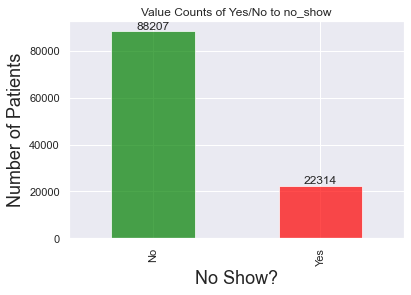

```python
colors = ['green', 'red']                        # setting colors I want to use
ax = no_show_count.plot(kind='bar', title='Value Counts of Yes/No to no_show', color=colors, alpha=.7) #creating a bar plot
ax.bar_label(ax.containers[0])                   # using this to set bar_labels see reference below
plt.xlabel('No Show?', fontsize=18)              # setting the x-axis label
plt.ylabel('Number of Patients', fontsize=18);   # setting the y-axis label
```

The appointments made are about 4 times the appointment missed.  
The line of code to set bar labels was gotten from this [stackoverflow page](https://stackoverflow.com/questions/70513596/how-to-calculate-percentage-for-row-counts-in-groupby-in-python-and-generate-bar).

```python
# divide the value_counts of each unique value in no_show column
# by the total number of counts in the no_show column
# multiply by 100 to get percentage and round value to 1d.p
percentage_count = ((df_cleaned["no_show"].value_counts()/df_cleaned["no_show"].count())*100).round(1)
percentage_count
```

```
No     79.8
Yes    20.2
Name: no_show, dtype: float64
```

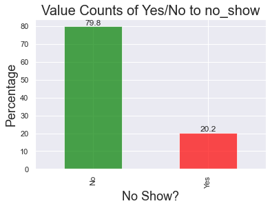

```python
# plot percentage_count
colors = ['green', 'red']
ax = percentage_count.plot(kind='bar', color=colors, alpha=.7)
ax.bar_label(ax.containers[0])
plt.title('Value Counts of Yes/No to no_show',fontsize=20)
plt.xlabel('No Show?', fontsize=18)
plt.ylabel('Percentage', fontsize=18);
```

### What proportion of each gender missed their appointments?

I want to see the distribution of the genders.  
Knowing I will be repeating this process of plotting value_counts for different columns, I will create a function for that.

We will be using seaborn's [countplot](https://seaborn.pydata.org/generated/seaborn.countplot.html) and catplot functions to help with some visualizations.

```python
def valcount_plot(col_name,df=df_cleaned):                             #define function name
    """
    This simple function plots the value counts of a speified column in a given dataframe
    column name "col_name" must be written as a string.
    default dataframe is df_cleaned
    """
    ax = sns.countplot(x=col_name, data=df)                # create countplot with just two argument (column name and dataframe)
    ax.bar_label(ax.containers[0])                  # setting bar labels
    plt.title("Value Counts of "+col_name.upper());        # Creating a related title for the plot
```

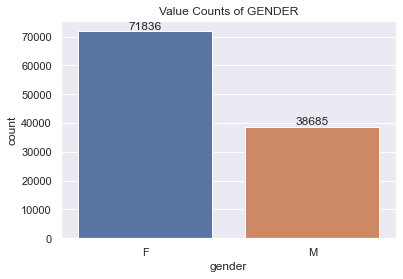

```python
valcount_plot("gender")
```

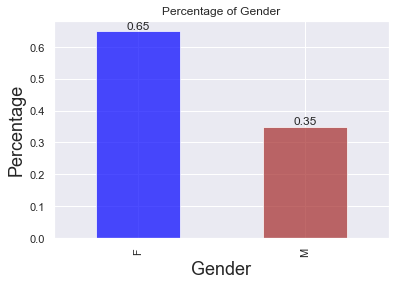

```python
# I'll find the percentages
colors = ['blue', 'brown']
genpercent_count = (df_cleaned["gender"].value_counts()/df_cleaned["gender"].count()).round(2)
ax = genpercent_count.plot(kind='bar', title='Percentage of Gender', color=colors, alpha=.7);
ax.bar_label(ax.containers[0])
plt.xlabel('Gender', fontsize=18)
plt.ylabel('Percentage', fontsize=18);
```

This shows more women visit these health centres than men.

I'll find the number of Male and Female with Yes/No to no_show.

```python
# Grouping by gender and no show columns to see the counts in each group
df_cleaned.groupby(["gender","no_show"]).count()
```

| gender | no_show | scheduled_day | scheduled_time | waiting_days | appointment_day | apnmnt_day_of_week | apnmnt_month_name | age | neighbourhood | handicap | scholarship | hypertension | diabetes | alcoholism | sms_received |
| --- | --- | --- | --- | --- | --- | --- | --- | --- | --- | --- | --- | --- | --- | --- | --- |
| F | No | 57245 | 57245 | 57245 | 57245 | 57245 | 57245 | 57245 | 57245 | 57245 | 57245 | 57245 | 57245 | 57245 | 57245 |
|  | Yes | 14591 | 14591 | 14591 | 14591 | 14591 | 14591 | 14591 | 14591 | 14591 | 14591 | 14591 | 14591 | 14591 | 14591 |
| M | No | 30962 | 30962 | 30962 | 30962 | 30962 | 30962 | 30962 | 30962 | 30962 | 30962 | 30962 | 30962 | 30962 | 30962 |
|  | Yes | 7723 | 7723 | 7723 | 7723 | 7723 | 7723 | 7723 | 7723 | 7723 | 7723 | 7723 | 7723 | 7723 | 7723 |

The table shows the counts of appointments for each group.

```python
# Create a function to plot bar graphs of intersecion of two categorical variables
def cat_count_plot(x,hue,df=df_cleaned):
    '''
    can takes in 3 parameters.
    first 2 are required.
    The two column names as strings x  and hue.
    First column name x forms the different sections in the graph
    and second column determines the nnumber of plots per section.
    df is df_cleaned by default, but can also be specified
    '''
    ax =sns.countplot(x=x, hue=hue, data=df)
    for i in range(len(ax.containers)):
        ax.bar_label(ax.containers[i])
    plt.title(f"Count of {x} per {hue}");
```

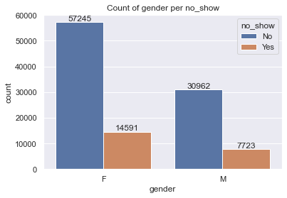

```python
cat_count_plot("gender","no_show")
```

I'll look at this in terms of percentage of the total no of appointments for each gender

```python
#  groupby gender and no_show then divide the count by total count of each gender
percent_gender = (df_cleaned.groupby(["gender","no_show"]).count()/df_cleaned.groupby(["gender"]).count()).round(3)
percent_gender
```

| gender | no_show | age | alcoholism | apnmnt_day_of_week | apnmnt_month_name | appointment_day | diabetes | handicap | hypertension | neighbourhood | no_show | scheduled_day | scheduled_time | scholarship | sms_received | waiting_days |
| --- | --- | --- | --- | --- | --- | --- | --- | --- | --- | --- | --- | --- | --- | --- | --- | --- |
| F | No | 0.797 | 0.797 | 0.797 | 0.797 | 0.797 | 0.797 | 0.797 | 0.797 | 0.797 | NaN | 0.797 | 0.797 | 0.797 | 0.797 | 0.797 |
|  | Yes | 0.203 | 0.203 | 0.203 | 0.203 | 0.203 | 0.203 | 0.203 | 0.203 | 0.203 | NaN | 0.203 | 0.203 | 0.203 | 0.203 | 0.203 |
| M | No | 0.800 | 0.800 | 0.800 | 0.800 | 0.800 | 0.800 | 0.800 | 0.800 | 0.800 | NaN | 0.800 | 0.800 | 0.800 | 0.800 | 0.800 |
|  | Yes | 0.200 | 0.200 | 0.200 | 0.200 | 0.200 | 0.200 | 0.200 | 0.200 | 0.200 | NaN | 0.200 | 0.200 | 0.200 | 0.200 | 0.200 |

The table shows the percent of males or females that miss or make their appointments.

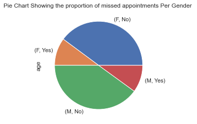

```python
# i just used ["age"] as a shortcut to get the count any other column name
# could have been used e.g.["diabetes"] because they all have the same no. of count
percent_gender["age"].plot(kind="pie")     #because thy aren't many portions, I will use a pie chart
plt.title("Pie Chart Showing the proportion of missed appointments Per Gender ");
```

Generally, there are clearly more females than males. Approximately, we have the same percentage of no shows in each gender.

##### Additionally, I'll see the age distribution for each gender.

```python
# first compute some stats
df_cleaned.groupby(["gender","no_show"])["age"].describe().round(1)
```

| gender | no_show | count | mean | std | min | 25% | 50% | 75% | max |
| --- | --- | --- | --- | --- | --- | --- | --- | --- | --- |
| F | No | 57245.0 | 39.6 | 22.3 | 0.0 | 22.0 | 40.0 | 57.0 | 115.0 |
|  | Yes | 14591.0 | 36.2 | 21.2 | 0.0 | 20.0 | 34.0 | 52.0 | 115.0 |
| M | No | 30962.0 | 34.5 | 24.7 | 0.0 | 10.0 | 34.0 | 55.0 | 100.0 |
|  | Yes | 7723.0 | 30.8 | 23.0 | 0.0 | 10.0 | 28.0 | 49.0 | 97.0 |

Not only are women more than men, they also live longer. The ages show that the average ages of females who have appointments is more than those of men.

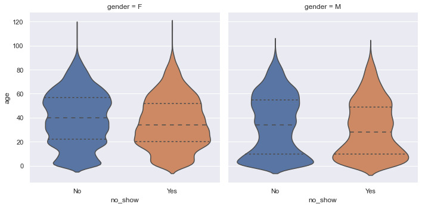

```python
sns.catplot(data=df_cleaned, x="no_show", y="age", col="gender", kind="violin",inner="quartile");
```

The middle lines shows the median age. While the top and bottom show the 75th and 25th percentile respectively. For both genders the mean and median ages of patients who made their appointments _(i.e no*show=="No")* is *"older"* than those who missed their appoinments.

This implies that younger people miss their appointments than older people. Maybe because younger people tend to be more busy and older have more time to monitor their health.

### What month, days and periods in the time line have the highest number of No_shows.

##### I'll observe the months and the count of appointment in each month.

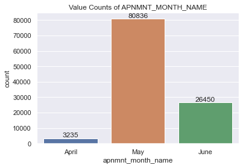

```python
# we can check using valcount_plots created earlier
valcount_plot("apnmnt_month_name")
```

May has more than 50% of the total number of appointments. Why was there a surge in May? If May isn't a surge then why were April and June low? I will look at the appointment dates to find out.

```python
# groupby appointment_day to see number of appointments and their respective dates
apnmnt_per_day = df_cleaned.groupby(["appointment_day"]).count()['no_show']
apnmnt_per_day
```

```
appointment_day
2016-04-29    3235
2016-05-02    4376
2016-05-03    4255
2016-05-04    4167
2016-05-05    4272
2016-05-06    3879
2016-05-09    4519
2016-05-10    4308
2016-05-11    4474
2016-05-12    4394
2016-05-13    3987
2016-05-14      39
2016-05-16    4613
2016-05-17    4371
2016-05-18    4373
2016-05-19    4270
2016-05-20    3828
2016-05-24    4009
2016-05-25    3909
2016-05-30    4514
2016-05-31    4279
2016-06-01    4464
2016-06-02    4310
2016-06-03    4090
2016-06-06    4691
2016-06-07    4416
2016-06-08    4479
Name: no_show, dtype: int64
```

```python
apnmnt_per_day.describe()
```

```
count      27.00000
mean     4093.37037
std       864.05743
min        39.00000
25%      4049.50000
50%      4308.00000
75%      4440.00000
max      4691.00000
Name: no_show, dtype: float64
```

```python
print(f"The median number of appointments per day is {round(apnmnt_per_day.median())}.")
print(f"The mean number of appointments per day is {round(apnmnt_per_day.mean())}.")
print(f"The date with the most number of appointments, {apnmnt_per_day.max()}, is {(apnmnt_per_day.idxmax())}.")
print(f"The date with the least number of appointments, {apnmnt_per_day.min()}, is {(apnmnt_per_day.idxmin())}.")
```

```
The median number of appointments per day is 4308.
The mean number of appointments per day is 4093.
The date with the most number of appointments, 4691, is 2016-06-06.
The date with the least number of appointments, 39, is 2016-05-14.
```

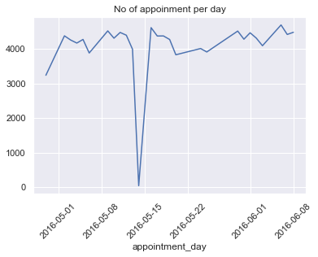

```python
apnmnt_per_day.plot()
plt.title("No of appoinment per day")
plt.xticks(rotation = 45);
```

The reason May has the highest number of appoinments is simple, it is the only month fully represented in the `appointment_day` column. April has only one day and June has six. Also 2016-05-14 seemed to be a really *no-appointments-today* kind of date  
Next, I will look at the proportion of made and missed appointments per day. And create a line plot.  
We can conclude that a regular working day for these health care centres has a combined value of over 4,000 appointments .

```python
# First query the data where no_show==No, then groupby appointment_day, and then get the count.
# Here too ["age"] can be anyother column name apart from what we are grouping by
# Which in this case is "appointment_day"
made_apnmnt_per_day = df_cleaned.query("no_show == 'No'").groupby(["appointment_day"]).count()["age"]


# do the same for where no_show==Yes
missed_apnmnt_per_day = df_cleaned.query("no_show == 'Yes'").groupby(["appointment_day"]).count()["age"]


# printing the first five elements of the pandas series
print(made_apnmnt_per_day[:5],"\n\n",missed_apnmnt_per_day[:5])
# printing the type just out of curiosity
type(made_apnmnt_per_day)
```

```
appointment_day
2016-04-29    2602
2016-05-02    3515
2016-05-03    3425
2016-05-04    3195
2016-05-05    3466
Name: age, dtype: int64

 appointment_day
2016-04-29    633
2016-05-02    861
2016-05-03    830
2016-05-04    972
2016-05-05    806
Name: age, dtype: int64
```

```
pandas.core.series.Series
```

```python
print(f"The median number of missed appointments per day is {round(missed_apnmnt_per_day.median())}")
print(f"The mean number of missed appointments per day is {round(missed_apnmnt_per_day.mean())}")
print(f"The date with the most number of missed appointments, {missed_apnmnt_per_day.max()}, is {(missed_apnmnt_per_day.idxmax())}")
print(f"The date with the least number of missed appointments, {missed_apnmnt_per_day.min()}, is {(missed_apnmnt_per_day.idxmin())}")
```

```
The median number of missed appointments per day is 837
The mean number of missed appointments per day is 826
The date with the most number of missed appointments, 1049, is 2016-05-16
The date with the least number of missed appointments, 9, is 2016-05-14
```

About 800 appointments are missed each day. So about 1 in every 5 appointment was missed daily.

```python
# divide the counts of each category per day by the total count of appointments per day
# rounding the values to make them look neater
made_proportions = (made_apnmnt_per_day / apnmnt_per_day).round(2)
missed_proportions = (missed_apnmnt_per_day / apnmnt_per_day).round(2)
```

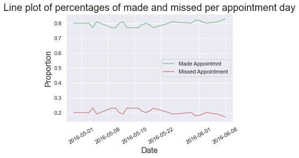

```python
# create the two line to have them on one plot
made_line = plt.plot(made_proportions, color='g', alpha=.7, label='Made Appointmnt')
missed_line = plt.plot(missed_proportions, color='r', alpha=.7, label='Missed Appointment')

plt.ylabel('Proportion',fontsize=16)
plt.xlabel('Date',fontsize=16)
plt.title('Line plot of percentages of made and missed per appointment day',fontsize=20)
plt.legend()                         # show legend
plt.xticks(rotation=30)              # rotating the xticks so they don't overlap
sns.set();                           # setting to us an seaborn theme
```

The two line plots resemble a mirror reflection of eachother. i.e The highest point in one is the lowest in the other and vice versa. As it should be.  
Next, I'll plot a summary of no_show in each month using the cat_count_plot function created earlier.

```python
# ? using help function to remember how it works
help(cat_count_plot)
```

[output not shown]

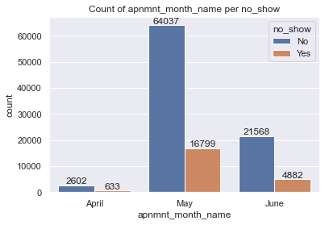

```python
cat_count_plot("apnmnt_month_name","no_show")
```

What relationships if any do sms_received and no_show columns have?

```python
df_cleaned.groupby(["apnmnt_month_name","no_show"])["sms_received"].describe().round(1)
```

| apnmnt_month_name | no_show | count | mean | std | min | 25% | 50% | 75% | max |
| --- | --- | --- | --- | --- | --- | --- | --- | --- | --- |
| April | No | 2602.0 | 0.4 | 0.5 | 0.0 | 0.0 | 0.0 | 1.0 | 1.0 |
|  | Yes | 633.0 | 0.5 | 0.5 | 0.0 | 0.0 | 1.0 | 1.0 | 1.0 |
| June | No | 21568.0 | 0.4 | 0.5 | 0.0 | 0.0 | 0.0 | 1.0 | 1.0 |
|  | Yes | 4882.0 | 0.6 | 0.5 | 0.0 | 0.0 | 1.0 | 1.0 | 1.0 |
| May | No | 64037.0 | 0.3 | 0.4 | 0.0 | 0.0 | 0.0 | 1.0 | 1.0 |
|  | Yes | 16799.0 | 0.4 | 0.5 | 0.0 | 0.0 | 0.0 | 1.0 | 1.0 |

The means imply that the percentage of people who received sms and didn't show up is more than the percentage of people who received sms reminders and made the appointment. What days of the week have higher no_shows?

Looking at the mean and median values, I assume that majority of the people who missed their appointments in June recieved an sms. Same thing goes for April.

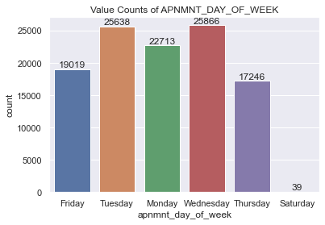

```python
valcount_plot("apnmnt_day_of_week")
```

Wednesday has the highest number of Appointments and Saturday has the least. After checking my calender I saw that 2016-05-14 was a Saturday.

Maybe these health care centres generally don't open on Saturdays and for some reason an exception was made for that particular date.

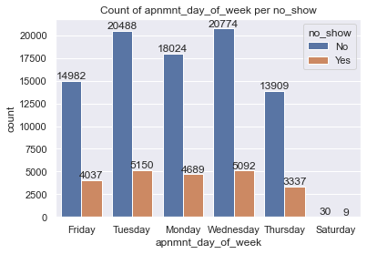

```python
cat_count_plot("apnmnt_day_of_week","no_show")
```

These numbers still show that the ratio of missed:made is even across the different days.

##### Distribution of waiting days

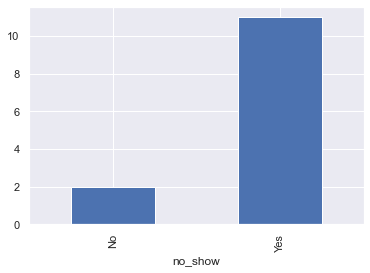

```python
df_cleaned.groupby("no_show")["waiting_days"].median().plot(kind="bar");
```

This implies a relationship between longer waiting days and missing appointments. People who have longer waiting days are more likely to miss their appoinment.

I want to explore some statistics between waiting_days, no_show and sms.

```python
df_cleaned.groupby(["no_show","sms_received"])["waiting_days"].describe().round(1)
```

| no_show | sms_received | count | mean | std | min | 25% | 50% | 75% | max |
| --- | --- | --- | --- | --- | --- | --- | --- | --- | --- |
| No | 0 | 62509.0 | 4.7 | 11.1 | 0.0 | 0.0 | 0.0 | 3.0 | 179.0 |
|  | 1 | 25698.0 | 18.6 | 17.0 | 3.0 | 6.0 | 14.0 | 27.0 | 179.0 |
| Yes | 0 | 12530.0 | 12.6 | 15.6 | 0.0 | 2.0 | 7.0 | 20.0 | 179.0 |
|  | 1 | 9784.0 | 20.0 | 17.0 | 3.0 | 7.0 | 15.0 | 28.0 | 179.0 |

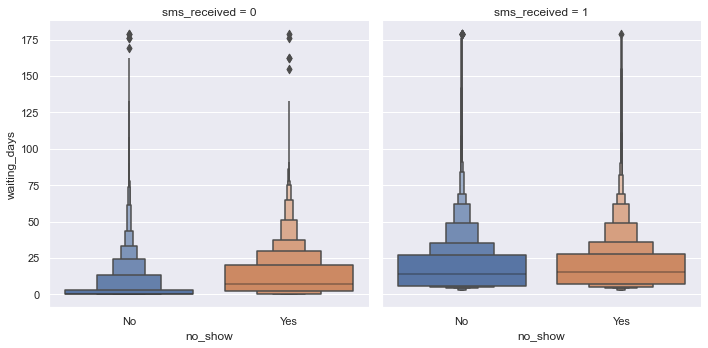

```python
sns.catplot(data=df_cleaned, x="no_show", y="waiting_days", col="sms_received", kind="boxen");
```

Observations

- A large number of people who made their appointments and didn't recieve a reminder are patients with 0 waiting days.
- SMS reminders weren't sent to patients with less than 3 waiting days.
- From this plot we can't see the or estimate well enough the number in each group.

### 3. What are the top neighbourhoods with missed appointments?

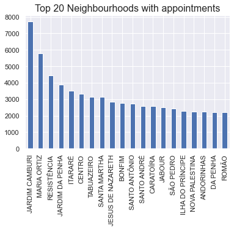

```python
# plotting the top 20 neigbourhoods with appointments
df_cleaned["neighbourhood"].value_counts()[:20].plot(kind="bar")
plt.title("Top 20 Neighbourhoods with appointments",fontsize=16);
```

```python
# Creating a df of only those who missed their appointments.
df_missed = df_cleaned[df_cleaned["no_show"]=="Yes"]
```

```python
df_missed
```

|  | gender | scheduled_day | scheduled_time | waiting_days | appointment_day | apnmnt_day_of_week | apnmnt_month_name | age | neighbourhood | handicap | scholarship | hypertension | diabetes | alcoholism | sms_received | no_show |
| --- | --- | --- | --- | --- | --- | --- | --- | --- | --- | --- | --- | --- | --- | --- | --- | --- |
| 6 | F | 2016-04-27 | 15 | 2 | 2016-04-29 | Friday | April | 23 | GOIABEIRAS | 0 | 0 | 0 | 0 | 0 | 0 | Yes |
| 7 | F | 2016-04-27 | 15 | 2 | 2016-04-29 | Friday | April | 39 | GOIABEIRAS | 0 | 0 | 0 | 0 | 0 | 0 | Yes |
| 11 | M | 2016-04-26 | 8 | 3 | 2016-04-29 | Friday | April | 29 | NOVA PALESTINA | 0 | 0 | 0 | 0 | 0 | 1 | Yes |
| 17 | F | 2016-04-28 | 9 | 1 | 2016-04-29 | Friday | April | 40 | CONQUISTA | 0 | 1 | 0 | 0 | 0 | 0 | Yes |
| 20 | F | 2016-04-27 | 7 | 2 | 2016-04-29 | Friday | April | 30 | NOVA PALESTINA | 0 | 0 | 0 | 0 | 0 | 0 | Yes |
| ... | ... | ... | ... | ... | ... | ... | ... | ... | ... | ... | ... | ... | ... | ... | ... | ... |
| 110484 | F | 2016-06-03 | 14 | 4 | 2016-06-07 | Tuesday | June | 45 | BARRO VERMELHO | 0 | 0 | 0 | 0 | 0 | 0 | Yes |
| 110492 | M | 2016-06-08 | 8 | 0 | 2016-06-08 | Wednesday | June | 33 | MARIA ORTIZ | 0 | 0 | 1 | 0 | 0 | 0 | Yes |
| 110496 | F | 2016-06-06 | 17 | 2 | 2016-06-08 | Wednesday | June | 37 | MARIA ORTIZ | 0 | 0 | 1 | 0 | 0 | 0 | Yes |
| 110515 | M | 2016-06-06 | 15 | 2 | 2016-06-08 | Wednesday | June | 33 | MARIA ORTIZ | 0 | 0 | 1 | 0 | 0 | 0 | Yes |
| 110516 | F | 2016-06-07 | 7 | 1 | 2016-06-08 | Wednesday | June | 37 | MARIA ORTIZ | 0 | 0 | 0 | 0 | 0 | 0 | Yes |

22314 rows × 16 columns

```python
# Extracting the top 20 neighbourhoods with missed appointments
df_missed["neighbourhood"].value_counts()[:20]
```

```
JARDIM CAMBURI       1465
MARIA ORTIZ          1219
ITARARÉ               923
RESISTÊNCIA           905
CENTRO                703
JESUS DE NAZARETH     696
JARDIM DA PENHA       631
CARATOÍRA             591
TABUAZEIRO            572
BONFIM                550
ILHA DO PRÍNCIPE      532
ANDORINHAS            521
SÃO PEDRO             515
SANTO ANDRÉ           508
SANTA MARTHA          496
SANTO ANTÔNIO         482
ROMÃO                 474
GURIGICA              456
JABOUR                451
DA PENHA              429
Name: neighbourhood, dtype: int64
```

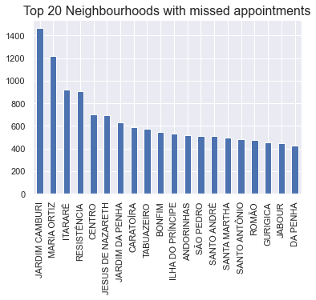

```python
# plotting a bar_graph for the locations with top 20 missed.
df_missed["neighbourhood"].value_counts()[:20].plot(kind="bar")
plt.title("Top 20 Neighbourhoods with missed appointments",fontsize=16);
```

```python
pd.crosstab(df_cleaned["neighbourhood"],df_cleaned["no_show"],margins=True).style.background_gradient(cmap='YlOrRd')
```

| no_show neighbourhood | No | Yes | All |
| --- | --- | --- | --- |
| AEROPORTO | 7 | 1 | 8 |
| ANDORINHAS | 1741 | 521 | 2262 |
| ANTÔNIO HONÓRIO | 221 | 50 | 271 |
| ARIOVALDO FAVALESSA | 220 | 62 | 282 |
| BARRO VERMELHO | 332 | 91 | 423 |
| BELA VISTA | 1523 | 384 | 1907 |
| BENTO FERREIRA | 665 | 193 | 858 |
| BOA VISTA | 254 | 58 | 312 |
| BONFIM | 2223 | 550 | 2773 |
| CARATOÍRA | 1974 | 591 | 2565 |
| CENTRO | 2631 | 703 | 3334 |
| COMDUSA | 254 | 56 | 310 |
| CONQUISTA | 689 | 160 | 849 |
| CONSOLAÇÃO | 1139 | 236 | 1375 |
| CRUZAMENTO | 1094 | 304 | 1398 |
| DA PENHA | 1788 | 429 | 2217 |
| DE LOURDES | 258 | 47 | 305 |
| DO CABRAL | 472 | 88 | 560 |
| DO MOSCOSO | 321 | 92 | 413 |
| DO QUADRO | 709 | 140 | 849 |
| ENSEADA DO SUÁ | 183 | 52 | 235 |
| ESTRELINHA | 432 | 106 | 538 |
| FONTE GRANDE | 533 | 149 | 682 |
| FORTE SÃO JOÃO | 1543 | 346 | 1889 |
| FRADINHOS | 210 | 48 | 258 |
| GOIABEIRAS | 563 | 137 | 700 |
| GRANDE VITÓRIA | 854 | 217 | 1071 |
| GURIGICA | 1562 | 456 | 2018 |
| HORTO | 133 | 42 | 175 |
| ILHA DAS CAIEIRAS | 836 | 235 | 1071 |

[output cut: 52 more lines]

The ranges in the type of values of these hospitals could be dependent on the type of health centres. Specialty clinics would have less patients in this time period than general hospitals. Maybe some information on hospital type might have helped understand the data more.

```python
pd.crosstab(df_cleaned["neighbourhood"],df_cleaned["appointment_day"],margins=True).style.background_gradient(cmap='YlOrRd')
```

| appointment_day neighbourhood | 2016-04-29 | 2016-05-02 | 2016-05-03 | 2016-05-04 | 2016-05-05 | 2016-05-06 | 2016-05-09 | 2016-05-10 | 2016-05-11 | 2016-05-12 | 2016-05-13 | 2016-05-14 | 2016-05-16 | 2016-05-17 | 2016-05-18 | 2016-05-19 | 2016-05-20 | 2016-05-24 | 2016-05-25 | 2016-05-30 | 2016-05-31 | 2016-06-01 | 2016-06-02 | 2016-06-03 | 2016-06-06 | 2016-06-07 | 2016-06-08 | All |
| --- | --- | --- | --- | --- | --- | --- | --- | --- | --- | --- | --- | --- | --- | --- | --- | --- | --- | --- | --- | --- | --- | --- | --- | --- | --- | --- | --- | --- |
| AEROPORTO | 0 | 0 | 0 | 0 | 1 | 1 | 1 | 0 | 0 | 1 | 0 | 0 | 0 | 1 | 0 | 0 | 0 | 0 | 0 | 0 | 0 | 0 | 1 | 1 | 1 | 0 | 0 | 8 |
| ANDORINHAS | 83 | 77 | 88 | 85 | 91 | 72 | 118 | 96 | 102 | 82 | 83 | 0 | 91 | 99 | 108 | 80 | 97 | 106 | 80 | 85 | 81 | 89 | 57 | 86 | 83 | 77 | 66 | 2262 |
| ANTÔNIO HONÓRIO | 4 | 4 | 8 | 7 | 9 | 13 | 12 | 10 | 6 | 8 | 9 | 0 | 18 | 8 | 11 | 16 | 7 | 11 | 18 | 11 | 16 | 9 | 13 | 6 | 14 | 11 | 12 | 271 |
| ARIOVALDO FAVALESSA | 8 | 12 | 11 | 7 | 13 | 12 | 4 | 9 | 12 | 20 | 17 | 5 | 9 | 10 | 8 | 7 | 14 | 8 | 4 | 14 | 6 | 15 | 10 | 7 | 15 | 12 | 13 | 282 |
| BARRO VERMELHO | 7 | 16 | 16 | 18 | 13 | 21 | 14 | 17 | 21 | 8 | 22 | 0 | 20 | 26 | 11 | 17 | 16 | 14 | 10 | 21 | 20 | 21 | 13 | 16 | 16 | 14 | 15 | 423 |
| BELA VISTA | 51 | 83 | 77 | 69 | 71 | 54 | 70 | 66 | 92 | 85 | 64 | 0 | 72 | 64 | 85 | 91 | 60 | 79 | 71 | 72 | 85 | 59 | 87 | 68 | 79 | 76 | 77 | 1907 |
| BENTO FERREIRA | 30 | 36 | 31 | 26 | 26 | 38 | 28 | 34 | 25 | 21 | 27 | 0 | 40 | 28 | 24 | 43 | 33 | 22 | 23 | 45 | 25 | 40 | 36 | 46 | 49 | 45 | 37 | 858 |
| BOA VISTA | 9 | 13 | 6 | 15 | 9 | 15 | 11 | 11 | 14 | 9 | 11 | 0 | 9 | 4 | 5 | 18 | 12 | 10 | 8 | 14 | 10 | 12 | 18 | 16 | 16 | 23 | 14 | 312 |
| BONFIM | 79 | 112 | 99 | 127 | 104 | 102 | 149 | 95 | 107 | 94 | 79 | 0 | 135 | 109 | 123 | 115 | 77 | 98 | 103 | 116 | 94 | 110 | 109 | 78 | 133 | 112 | 114 | 2773 |
| CARATOÍRA | 89 | 72 | 112 | 80 | 117 | 111 | 63 | 84 | 106 | 118 | 106 | 30 | 101 | 99 | 81 | 127 | 101 | 99 | 86 | 93 | 82 | 106 | 106 | 97 | 108 | 100 | 91 | 2565 |
| CENTRO | 109 | 134 | 159 | 102 | 118 | 122 | 137 | 139 | 113 | 112 | 130 | 0 | 143 | 139 | 106 | 103 | 109 | 134 | 114 | 165 | 141 | 157 | 120 | 139 | 158 | 113 | 118 | 3334 |
| COMDUSA | 9 | 10 | 10 | 8 | 10 | 13 | 14 | 14 | 7 | 12 | 19 | 0 | 10 | 11 | 6 | 14 | 18 | 11 | 13 | 18 | 12 | 10 | 13 | 13 | 10 | 11 | 14 | 310 |
| CONQUISTA | 33 | 43 | 40 | 29 | 24 | 25 | 37 | 34 | 31 | 32 | 31 | 0 | 41 | 37 | 37 | 31 | 24 | 38 | 22 | 32 | 36 | 25 | 32 | 23 | 46 | 37 | 29 | 849 |
| CONSOLAÇÃO | 47 | 52 | 68 | 53 | 60 | 35 | 36 | 58 | 67 | 69 | 59 | 0 | 51 | 49 | 53 | 61 | 54 | 49 | 41 | 59 | 32 | 54 | 59 | 58 | 59 | 54 | 38 | 1375 |
| CRUZAMENTO | 52 | 61 | 61 | 60 | 44 | 45 | 49 | 65 | 47 | 49 | 65 | 0 | 66 | 50 | 45 | 49 | 54 | 55 | 41 | 59 | 49 | 59 | 45 | 61 | 55 | 57 | 55 | 1398 |
| DA PENHA | 39 | 98 | 75 | 112 | 83 | 73 | 109 | 79 | 79 | 84 | 65 | 0 | 108 | 60 | 73 | 78 | 62 | 57 | 76 | 96 | 84 | 103 | 78 | 107 | 115 | 124 | 100 | 2217 |
| DE LOURDES | 9 | 16 | 10 | 15 | 12 | 14 | 19 | 8 | 12 | 13 | 1 | 0 | 11 | 18 | 6 | 9 | 13 | 4 | 13 | 12 | 14 | 11 | 12 | 12 | 14 | 14 | 13 | 305 |
| DO CABRAL | 9 | 28 | 14 | 22 | 15 | 17 | 29 | 20 | 29 | 18 | 16 | 0 | 34 | 28 | 31 | 21 | 19 | 26 | 31 | 22 | 18 | 8 | 20 | 31 | 22 | 5 | 27 | 560 |
| DO MOSCOSO | 18 | 20 | 13 | 20 | 12 | 17 | 9 | 21 | 11 | 11 | 16 | 0 | 16 | 20 | 15 | 15 | 9 | 9 | 8 | 11 | 19 | 24 | 20 | 11 | 18 | 35 | 15 | 413 |
| DO QUADRO | 27 | 31 | 48 | 38 | 35 | 34 | 37 | 26 | 51 | 39 | 39 | 1 | 37 | 30 | 44 | 28 | 41 | 25 | 22 | 36 | 37 | 32 | 16 | 33 | 24 | 15 | 23 | 849 |
| ENSEADA DO SUÁ | 3 | 9 | 9 | 6 | 7 | 12 | 7 | 9 | 6 | 20 | 9 | 0 | 10 | 7 | 9 | 5 | 2 | 6 | 9 | 11 | 10 | 14 | 17 | 11 | 11 | 8 | 8 | 235 |
| ESTRELINHA | 12 | 26 | 17 | 25 | 16 | 7 | 17 | 18 | 22 | 20 | 19 | 0 | 31 | 28 | 28 | 17 | 23 | 20 | 21 | 18 | 29 | 28 | 18 | 14 | 15 | 18 | 31 | 538 |
| FONTE GRANDE | 14 | 10 | 22 | 19 | 22 | 31 | 21 | 28 | 22 | 40 | 41 | 0 | 26 | 30 | 28 | 31 | 28 | 41 | 22 | 19 | 21 | 31 | 29 | 34 | 11 | 30 | 31 | 682 |
| FORTE SÃO JOÃO | 77 | 77 | 67 | 59 | 63 | 96 | 79 | 57 | 78 | 71 | 80 | 0 | 85 | 76 | 65 | 60 | 76 | 74 | 76 | 81 | 82 | 65 | 60 | 63 | 75 | 81 | 66 | 1889 |
| FRADINHOS | 6 | 9 | 3 | 9 | 12 | 13 | 13 | 9 | 14 | 10 | 8 | 0 | 12 | 6 | 7 | 10 | 13 | 8 | 8 | 12 | 12 | 14 | 14 | 6 | 10 | 11 | 9 | 258 |
| GOIABEIRAS | 17 | 22 | 31 | 19 | 15 | 16 | 30 | 24 | 34 | 21 | 16 | 0 | 17 | 23 | 35 | 23 | 26 | 27 | 23 | 31 | 26 | 28 | 27 | 44 | 48 | 42 | 35 | 700 |
| GRANDE VITÓRIA | 32 | 40 | 45 | 36 | 33 | 27 | 50 | 21 | 60 | 51 | 38 | 0 | 38 | 58 | 48 | 65 | 36 | 50 | 48 | 31 | 27 | 39 | 42 | 45 | 38 | 41 | 32 | 1071 |
| GURIGICA | 85 | 86 | 70 | 80 | 93 | 89 | 109 | 71 | 110 | 107 | 83 | 0 | 77 | 74 | 64 | 82 | 66 | 48 | 52 | 88 | 66 | 58 | 59 | 65 | 93 | 74 | 69 | 2018 |
| HORTO | 6 | 7 | 8 | 6 | 10 | 8 | 10 | 5 | 10 | 5 | 6 | 0 | 11 | 8 | 14 | 1 | 7 | 6 | 5 | 5 | 3 | 7 | 2 | 5 | 6 | 6 | 8 | 175 |
| ILHA DAS CAIEIRAS | 29 | 50 | 44 | 38 | 36 | 55 | 58 | 45 | 46 | 35 | 49 | 0 | 55 | 40 | 49 | 27 | 39 | 55 | 62 | 27 | 41 | 61 | 22 | 17 | 40 | 14 | 37 | 1071 |

[output cut: 52 more lines]

From the cross tab above we see that the date 2016-05-14 which is the date with the least number of appointments had only 4 centres recieve patients on that date. Of which Caratoira had the most appointments that date with 30.

### 4 Do health conditions make people miss their appointments?

I'll create a function using a modification of the previous date line plot I did here.

plot

```python
def prop_plot(col):
    """Takes one positional argument col
    col is the column name """

    # groupby col to see number of appointments
    apnmnt_per_col = df_cleaned.groupby([col]).count()['no_show']

    # First query the data where no_show==No, then groupby col, and then get the count.
    # Here too ["age"] can be anyother column name apart from what we are grouping by
    # Which in this case is col
    made_apnmnt_per_col = df_cleaned.query("no_show == 'No'").groupby(col).count()["age"]
    # do the same for where no_show==Yes
    missed_apnmnt_per_col = df_cleaned.query("no_show == 'Yes'").groupby(col).count()["age"]

    # divide the counts of each category per unique value by the total count of appointments per day
    # round the values to make them look neater
    # print the results so I can know the value names directly
    made_proportions = (made_apnmnt_per_col / apnmnt_per_col).round(2)
    print(f"made_proportions\n{made_proportions}")
    missed_proportions = (missed_apnmnt_per_col / apnmnt_per_col).round(2)
    print(f"missed_proportions\n{missed_proportions}")

    # create the two bars to have them in one plot
    ind = np.arange(len(made_proportions))
    width = 0.35
    made_bars = plt.bar(ind, made_proportions, width, color='g', alpha=.7, label='Made Appointment')
    missed_bars = plt.bar(ind + width, missed_proportions, width, color='r', alpha=.7, label='Missed Appointment')

    plt.ylabel('Percentage',fontsize=16)
    plt.xlabel(col,fontsize=16)
    plt.title(f'Proportion by  and {col.upper()}and NO_SHOW')
    locations = ind + width / 2  # xtick locations
    labels = df_cleaned[col].unique()  # xtick labels
    plt.xticks(locations, labels)
    plt.legend()                         # show legend
    plt.xticks(rotation=30)              # rotating the xticks so they don't overlap
    sns.set();                           # setting to us an seaborn theme
```

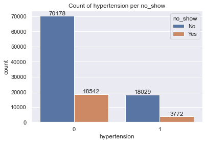

```python
cat_count_plot("hypertension","no_show")
```

```
made_proportions
hypertension
0    0.79
1    0.83
dtype: float64
missed_proportions
hypertension
0    0.21
1    0.17
dtype: float64
```

[figure not shown]

```python
prop_plot("hypertension")
```

```python
# groupby col to see number of appointments
apnmnt_per_col = df_cleaned.groupby(["hypertension"]).count()['no_show']
apnmnt_per_col
```

```
hypertension
0    88720
1    21801
Name: no_show, dtype: int64
```

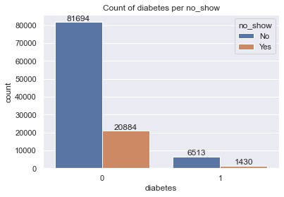

```python
cat_count_plot("diabetes","no_show")
```

```
made_proportions
diabetes
0    0.80
1    0.82
dtype: float64
missed_proportions
diabetes
0    0.20
1    0.18
dtype: float64
```

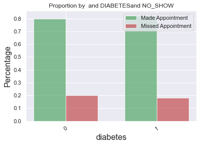

```python
prop_plot("diabetes")
```

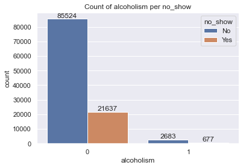

```python
cat_count_plot("alcoholism","no_show")
```

```
made_proportions
alcoholism
0    0.8
1    0.8
dtype: float64
missed_proportions
alcoholism
0    0.2
1    0.2
dtype: float64
```

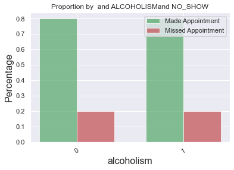

```python
prop_plot("alcoholism")
```

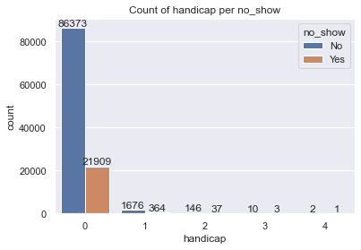

```python
cat_count_plot("handicap","no_show")
```

```
made_proportions
handicap
0    0.80
1    0.82
2    0.80
3    0.77
4    0.67
dtype: float64
missed_proportions
handicap
0    0.20
1    0.18
2    0.20
3    0.23
4    0.33
dtype: float64
```

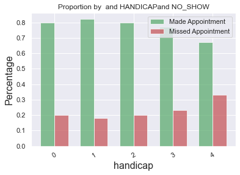

```python
prop_plot("handicap")
```

The trends from the statistics in the plots show similarities having and not having a certain health condition. Patients missing or making appointments is more related to the no_show column's 80/20 split of No/Yes than if they have a certain health condition.

## Conclusions

More research can be done on how the time the appointment was scheduled affects missing or making the appointment. More explorations could have been done on age groups and health conditions, if there are any relations and how that affects the no_show column. Lastly, changing the "No", "Yes" in the no_show column to "1", "0" and then doing a correlation plot would give insight as to how the numerical features are related.

Limitations

> A little more understanding of the geography of these neighboorhood would have helped me be able to make more group plots as plotting over 81 unique values would have been difficult to visualize. Also the time of the appointment itself ight have been more useful than the time the appointment was scheduled.

**List of reference links**

[Applying heatmaps for categorical data analysis](https://www.kaggle.com/code/tsilveira/applying-heatmaps-for-categorical-data-analysis)  
[SNS catplots](https://seaborn.pydata.org/generated/seaborn.catplot.html#seaborn.catplot)  
[SNS countplot](https://seaborn.pydata.org/generated/seaborn.countplot.html)  
[How to calculate percentage for row counts in groupby in Python and generate bar plot](https://stackoverflow.com/questions/70513596/how-to-calculate-percentage-for-row-counts-in-groupby-in-python-and-generate-bar)  
[Markdown Cheatsheet by Adam](https://github.com/adam-p/markdown-here/wiki/Markdown-Cheatsheet)

```python
from subprocess import call
call(['python', '-m', 'nbconvert', 'Investigate_a_Dataset.ipynb'])
```

```
4294967295
```